# Reproducible Report

Tiffany Hanratty

12/20/2021

## Introduction

This report consists of a re-analysis of the training portion found in Holmes, To, & Johnsrude (2021).

The article citation is: Holmes, E., To, G., & Johnsrude, I. S. (2021). How Long Does It Take for a Voice to Become Familiar? Speech Intelligibility and Voice Recognition Are Differentially Sensitive to Voice Training. Psychological science, 32(6), 903–915. https://doi.org/10.1177/0956797621991137

The data for this reproducible report were downloaded from https://osf.io/7kdyc/

## Re-analysis

```r
library(data.table)
library(dplyr)
```

```r
library(ggplot2)
library(papaja)

all_data <- read.csv("SemesterProject/Training_PercentCorrect_(n=50).csv")

(match_1 <- t.test(all_data$fam_1,
                  all_data$fam_2,
                  paired = TRUE))
```

```
##
##  Paired t-test
##
## data:  all_data$fam_1 and all_data$fam_2
## t = 4.2875, df = 49, p-value = 8.447e-05
## alternative hypothesis: true difference in means is not equal to 0
## 95 percent confidence interval:
##  2.036763 5.630437
## sample estimates:
## mean of the differences
##                  3.8336
```

```r
(match_2 <- t.test(all_data$fam_1,
                  all_data$fam_3,
                  paired = TRUE))
```

```
##
##  Paired t-test
##
## data:  all_data$fam_1 and all_data$fam_3
## t = 3.5619, df = 49, p-value = 0.0008311
## alternative hypothesis: true difference in means is not equal to 0
## 95 percent confidence interval:
##  1.709717 6.136283
## sample estimates:
## mean of the differences
##                   3.923
```

```r
(match_3 <- t.test(all_data$fam_2,
                  all_data$fam_3,
                  paired = TRUE))
```

```
##
##  Paired t-test
##
## data:  all_data$fam_2 and all_data$fam_3
## t = 0.15586, df = 49, p-value = 0.8768
## alternative hypothesis: true difference in means is not equal to 0
## 95 percent confidence interval:
##  -1.063256  1.242056
## sample estimates:
## mean of the differences
##                  0.0894
```

## Table of Means

```r
library(tidyr)

fam_df <- all_data %>%
  pivot_longer(cols = 1:3,
               names_to = c("name", "value"),
               names_sep = "_",
               values_to = "RTs")



overall_means <- fam_df %>%
  group_by(value, name) %>%
  summarise(meanRT = mean(RTs),
            SEMRT = (sd(RTs)/sqrt(length(RTs))))
knitr::kable(overall_means)
```

| value | name | meanRT | SEMRT |
| --- | --- | --- | --- |
| 1 | fam | 98.2568 | 0.2078432 |
| 2 | fam | 94.4232 | 1.0142461 |
| 3 | fam | 94.3338 | 1.1859128 |

## Graph of Means

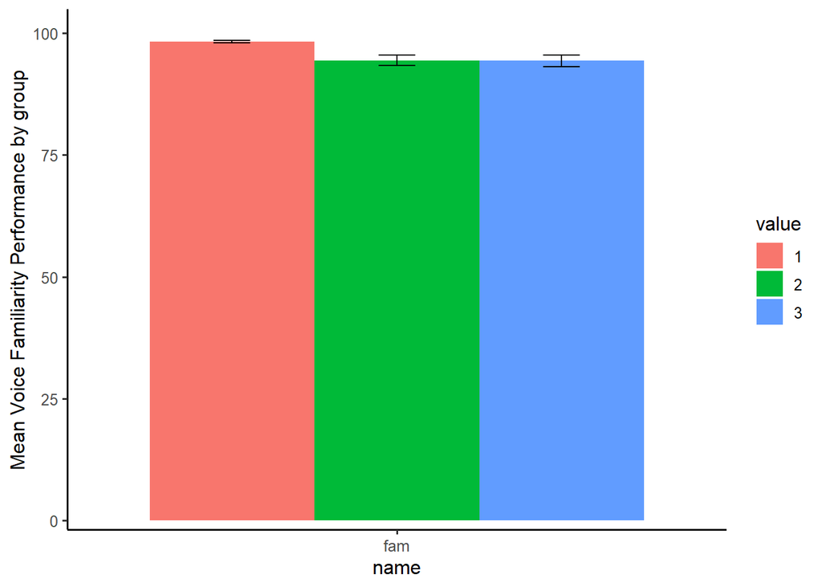

```r
ggplot(overall_means, aes(x=name,
                          y=meanRT,
                          group=value,
                          fill=value))+
  geom_bar(stat="identity",position="dodge")+
  theme_classic(base_size=12)+
  ylab("Mean Voice Familiarity Performance by group")+
  geom_errorbar(aes(ymin=meanRT-SEMRT,
                    ymax=meanRT+SEMRT),
                position=position_dodge(width=0.9),
                width=.2,
                color="black")+
  coord_cartesian(ylim=c(3,100))
```

## Results

A paired t-test was used to compare familiarity conditions with performance. Better performance was seen in the most familiar condition compared to the moderately familiar condition, t(49) = 4.29, p < .001 (Holmes, To, and Johnsrude, 2021). There was also better performance seen in the most familiar condition compared to the least familiar condition, t(49) = 3.56, p = .001 (Holmes, To, and Johnsrude, 2021). There was not a significant difference found in the moderately familiar group compared to the least familiar group, t(49) = 0.16, p = .88. The confidence interval values were not able to be reproduced in this reanalysis.

## Discussion

In this re-analysis of the triang portion of Holmes, To, & Johnsrude (2021), t-test values, as well as, p-values for each comparison condition matched those reopeted in the original article.